# **Weight Factoring**

The weight factor: $ \sqrt{c_p \rho \Delta d_{i,i-1} \cos{\phi}\Delta \theta \Delta \phi }$ is applied to account for 2 main factors: physical space and materialistic properties,.

The physical space factoring can be explained by viewing each gridbox as a rectangular prism. The volume would be $ V = Bh$. Base area is $ \Delta \theta \Delta \phi$ and the height is the thickness, or $\Delta d_{i,i-1}$. The $\cos \phi$ accounts for the spherical nature of the Earth because the Earth bulges near the equator and converges near the poles.

The materialistic properties account for the differing properties of air and water. Density even varies within air. A gridbox of air in a high altitude has less air then a gridbox of air near sea level, despite having the same volume. Likewise, heat capacity is taken into account for the difference in the transfer of heat between water and air.

# **Weight Calculations**

Some additional side calculations will be needed for the weight factoring. For example, in the NOAA air dataset, the levels are given in terms of pressure (hPa) instead of altitude (m). To fix this,$P = P_0 e^{\frac{-gM(h-h_0}{RT}}$ is used. Some assumptions are made: air pressure at sea level is consistently 1013.25 mbar and (since temperature varies), $T = climatology$ in Kelvin. Density must also be calculated. For water, all layers are assumed to be $1000 \frac{kg}{m^3}$ whereas for air, the equation: $ \rho = \frac{P}{2.869T}$.

Now the weighted anomalies can be calculated show below:

```python
vweightedanom = stnd_anom * weightFactor
```

# **EOF Calculations**

After dropping Nans for calculations, we can compute the Covariance matrix and find the respective eigenvectors show below:

```python
covariance = np.matmul(NanlessAnom.T, NanlessAnom)
eigenvalues, eigenvectors = scipy.linalg.eig(covariance)
#Because python reads row wise instead of column wise
eigenvectors = eigenvectors.T
```

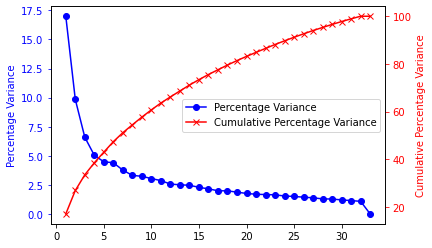

```python
#The scree plot explains the total variance that the respective eigenvector accounts for. In this example, the first eigenvector
#accounts for 17% of the total variance while the last eigenvector accounts for nearly 0 of the variance.
```

```python
EOFS = []

for j in range(0,stnd_anom.shape[1]):
        EOFS.append(np.matmul(vweightedAnom, eigvecs[j])/np.linalg.norm(np.matmul(NanlessAnom, eigvecs[j])))
EOFS = np.array(EOFS).T
```

```python
#The physical EOFs are the EOFs brought back to physical space. So we divide out our orignal weight factor
PhysicalEOFs = EOFS/weightFactor
```

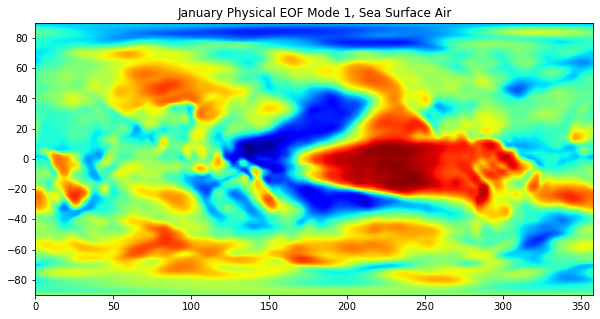

```python
#This is a layer in EOF mode 1, which according to our scree plot, makes up 17% of the thermal variance in air.
```